# Boston Housing Price Prediction

Dae Woong Yeo

## 0. Purpose

- **Boston dataset의 MEDV(집값)을 예측하는 모형 개발**

## 1. Data Loading

- **데이터를 read.table을 통해 로딩하고, 변수명을 할당**

```r
# library(ggplot2)
# library(dplyr)
# library(tidyverse)

#Boston data load
boston <- read.table("housing.data", head=F, encoding="utf-8")

#preserve raw
boston_raw <- boston

#assgin colnames
colnames(boston_raw) <- c("CRIM", "ZN", "INDUS", "CHAS", "NOX", "RM", "AGE", "DIS", "RAD", "TAX", "PTRATIO", "B1000", "LSTAT", "MEDV")
boston_raw <-as.data.frame(boston_raw)
```

## 2. Boston dataset description

[Target]

```
1. MEDV : 본인 소유의 주택가격(중앙값) (단위: $1,000)
```

[Predictors]

```
1. CRIM : 자치시(town)별 1인당 범죄율
2. ZN : 25,000 평방피트를 초과하는 거주지역의 비율
3. INDUS : 비소매상업지역이 점유하고 있는 토지의 비율
4. CHAS : 찰스강에 대한 더미변수
             - 강의 경계에 위치한 경우 : 1
             - 그 밖의 경우 : 0
5. NOX : 10ppm 당 농축 일산화질소
6. RM : 주택 1가구당 평균 방의 개수
7. AGE : 1940년 이전에 건축된 소유주택의 비율
8. DIS : 5개의 보스턴 직업센터까지의 접근성 지수
9. RAD : 방사형 도로까지의 접근성 지수
10. TAX : 10,000 달러 당 재산세율
11. PTRATIO : 자치시(town)별 학생/교사 비율
12. B1000 : 자치시별 흑인의 비율
13. LSTAT :모집단의 하위계층의 비율(%)
```

| CRIM | ZN | INDUS | CHAS | NOX | RM | AGE | DIS | RAD | TAX | PTRATIO | B1000 | LSTAT | MEDV |
| --- | --- | --- | --- | --- | --- | --- | --- | --- | --- | --- | --- | --- | --- |
| 0.00632 | 18.0 | 2.31 | 0 | 0.538 | 6.575 | 65.2 | 4.0900 | 1 | 296 | 15.3 | 396.90 | 4.98 | 24.0 |
| 0.02731 | 0.0 | 7.07 | 0 | 0.469 | 6.421 | 78.9 | 4.9671 | 2 | 242 | 17.8 | 396.90 | 9.14 | 21.6 |
| 0.02729 | 0.0 | 7.07 | 0 | 0.469 | 7.185 | 61.1 | 4.9671 | 2 | 242 | 17.8 | 392.83 | 4.03 | 34.7 |
| 0.03237 | 0.0 | 2.18 | 0 | 0.458 | 6.998 | 45.8 | 6.0622 | 3 | 222 | 18.7 | 394.63 | 2.94 | 33.4 |
| 0.06905 | 0.0 | 2.18 | 0 | 0.458 | 7.147 | 54.2 | 6.0622 | 3 | 222 | 18.7 | 396.90 | 5.33 | 36.2 |
| 0.02985 | 0.0 | 2.18 | 0 | 0.458 | 6.430 | 58.7 | 6.0622 | 3 | 222 | 18.7 | 394.12 | 5.21 | 28.7 |
| 0.08829 | 12.5 | 7.87 | 0 | 0.524 | 6.012 | 66.6 | 5.5605 | 5 | 311 | 15.2 | 395.60 | 12.43 | 22.9 |
| 0.14455 | 12.5 | 7.87 | 0 | 0.524 | 6.172 | 96.1 | 5.9505 | 5 | 311 | 15.2 | 396.90 | 19.15 | 27.1 |
| 0.21124 | 12.5 | 7.87 | 0 | 0.524 | 5.631 | 100.0 | 6.0821 | 5 | 311 | 15.2 | 386.63 | 29.93 | 16.5 |
| 0.17004 | 12.5 | 7.87 | 0 | 0.524 | 6.004 | 85.9 | 6.5921 | 5 | 311 | 15.2 | 386.71 | 17.10 | 18.9 |

```
 - Boston data dimension (row col) :  506 14
```

## 3. Training set, Test set Spliting

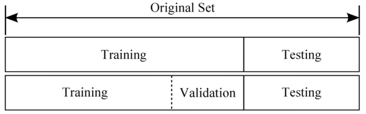

- Training set : Test set 은 9 : 1의 비율로 나눔
- Random seed 1로 고정

```r
set.seed(1)
train <- sample(nrow(boston_raw), nrow(boston_raw)*0.9) #index for training set
boston_ <- boston_raw[train,] #training set with index
boston_test <- boston_raw[-train,] #test set with left index
```

**[Training dataset]**

|  | CRIM | ZN | INDUS | CHAS | NOX | RM | AGE | DIS | RAD | TAX | PTRATIO | B1000 | LSTAT | MEDV |
| --- | --- | --- | --- | --- | --- | --- | --- | --- | --- | --- | --- | --- | --- | --- |
| 505 | 0.11 | 0 | 11.93 | 0 | 0.57 | 6.79 | 89.3 | 2.39 | 1 | 273 | 21.0 | 393.45 | 6.48 | 22.0 |
| 324 | 0.28 | 0 | 7.38 | 0 | 0.49 | 5.71 | 74.3 | 4.72 | 5 | 287 | 19.6 | 391.13 | 11.74 | 18.5 |
| 167 | 2.01 | 0 | 19.58 | 0 | 0.60 | 7.93 | 96.2 | 2.05 | 5 | 403 | 14.7 | 369.30 | 3.70 | 50.0 |
| 129 | 0.33 | 0 | 21.89 | 0 | 0.62 | 6.43 | 98.8 | 1.81 | 4 | 437 | 21.2 | 396.90 | 15.39 | 18.0 |
| 418 | 25.94 | 0 | 18.10 | 0 | 0.68 | 5.30 | 89.1 | 1.65 | 24 | 666 | 20.2 | 127.36 | 26.64 | 10.4 |
| 471 | 4.35 | 0 | 18.10 | 0 | 0.58 | 6.17 | 84.0 | 3.03 | 24 | 666 | 20.2 | 396.90 | 16.29 | 19.9 |
| 299 | 0.06 | 70 | 2.24 | 0 | 0.40 | 6.34 | 20.1 | 7.83 | 5 | 358 | 14.8 | 368.24 | 4.97 | 22.5 |
| 270 | 0.09 | 20 | 6.96 | 1 | 0.46 | 5.92 | 61.5 | 3.92 | 3 | 223 | 18.6 | 391.34 | 13.65 | 20.7 |
| 466 | 3.16 | 0 | 18.10 | 0 | 0.66 | 5.76 | 48.2 | 3.07 | 24 | 666 | 20.2 | 334.40 | 14.13 | 19.9 |
| 187 | 0.06 | 0 | 2.46 | 0 | 0.49 | 7.83 | 53.6 | 3.20 | 3 | 193 | 17.8 | 392.63 | 4.45 | 50.0 |

```
   - Training set dimension (row col) :  455 14
```

**[Test dataset]**

|  | CRIM | ZN | INDUS | CHAS | NOX | RM | AGE | DIS | RAD | TAX | PTRATIO | B1000 | LSTAT | MEDV |
| --- | --- | --- | --- | --- | --- | --- | --- | --- | --- | --- | --- | --- | --- | --- |
| 10 | 0.17 | 12.5 | 7.87 | 0 | 0.52 | 6.00 | 85.9 | 6.59 | 5 | 311 | 15.2 | 386.71 | 17.10 | 18.9 |
| 54 | 0.05 | 21.0 | 5.64 | 0 | 0.44 | 6.00 | 21.4 | 6.81 | 4 | 243 | 16.8 | 396.90 | 8.43 | 23.4 |
| 57 | 0.02 | 85.0 | 0.74 | 0 | 0.41 | 6.38 | 35.7 | 9.19 | 2 | 313 | 17.3 | 396.90 | 5.77 | 24.7 |
| 76 | 0.10 | 0.0 | 12.83 | 0 | 0.44 | 6.29 | 45.0 | 4.50 | 5 | 398 | 18.7 | 383.23 | 8.94 | 21.4 |
| 87 | 0.05 | 0.0 | 4.49 | 0 | 0.45 | 6.02 | 45.1 | 4.43 | 3 | 247 | 18.5 | 395.99 | 12.86 | 22.5 |
| 88 | 0.07 | 0.0 | 4.49 | 0 | 0.45 | 6.12 | 56.8 | 3.75 | 3 | 247 | 18.5 | 395.15 | 8.44 | 22.2 |
| 94 | 0.03 | 28.0 | 15.04 | 0 | 0.46 | 6.21 | 28.9 | 3.67 | 4 | 270 | 18.2 | 396.33 | 6.21 | 25.0 |
| 109 | 0.13 | 0.0 | 8.56 | 0 | 0.52 | 6.47 | 97.1 | 2.43 | 5 | 384 | 20.9 | 395.24 | 12.27 | 19.8 |
| 136 | 0.56 | 0.0 | 21.89 | 0 | 0.62 | 6.34 | 98.2 | 2.11 | 4 | 437 | 21.2 | 394.67 | 16.96 | 18.1 |
| 137 | 0.32 | 0.0 | 21.89 | 0 | 0.62 | 5.94 | 93.5 | 1.97 | 4 | 437 | 21.2 | 378.25 | 16.90 | 17.4 |

```
 - Test set dimension (row col):  51 14
```

## 4. Multiple Linear regression model 적합을 위한 변수탐색

- *예측모형으로 Multiple Linear regression 사용*
- *집값(양적변수) 예측문제에 적합*
- *다차원 공간상에서 선형 초평면(hyper-plane)을 찾는 문제*

**1) 선형회귀모형 가정 시 제약사항 확인**

```r
lmfit <- lm(MEDV~., data=boston_raw)
summary(lmfit)
```

```
##
## Call:
## lm(formula = MEDV ~ ., data = boston_raw)
##
## Residuals:
##     Min      1Q  Median      3Q     Max
## -15.595  -2.730  -0.518   1.777  26.199
##
## Coefficients:
##               Estimate Std. Error t value Pr(>|t|)
## (Intercept)  3.646e+01  5.103e+00   7.144 3.28e-12 ***
## CRIM        -1.080e-01  3.286e-02  -3.287 0.001087 **
## ZN           4.642e-02  1.373e-02   3.382 0.000778 ***
## INDUS        2.056e-02  6.150e-02   0.334 0.738288
## CHAS         2.687e+00  8.616e-01   3.118 0.001925 **
## NOX         -1.777e+01  3.820e+00  -4.651 4.25e-06 ***
## RM           3.810e+00  4.179e-01   9.116  < 2e-16 ***
## AGE          6.922e-04  1.321e-02   0.052 0.958229
## DIS         -1.476e+00  1.995e-01  -7.398 6.01e-13 ***
## RAD          3.060e-01  6.635e-02   4.613 5.07e-06 ***
## TAX         -1.233e-02  3.760e-03  -3.280 0.001112 **
## PTRATIO     -9.527e-01  1.308e-01  -7.283 1.31e-12 ***
## B1000        9.312e-03  2.686e-03   3.467 0.000573 ***
## LSTAT       -5.248e-01  5.072e-02 -10.347  < 2e-16 ***
## ---
## Signif. codes:  0 '***' 0.001 '**' 0.01 '*' 0.05 '.' 0.1 ' ' 1
##
## Residual standard error: 4.745 on 492 degrees of freedom
## Multiple R-squared:  0.7406, Adjusted R-squared:  0.7338
## F-statistic: 108.1 on 13 and 492 DF,  p-value: < 2.2e-16
```

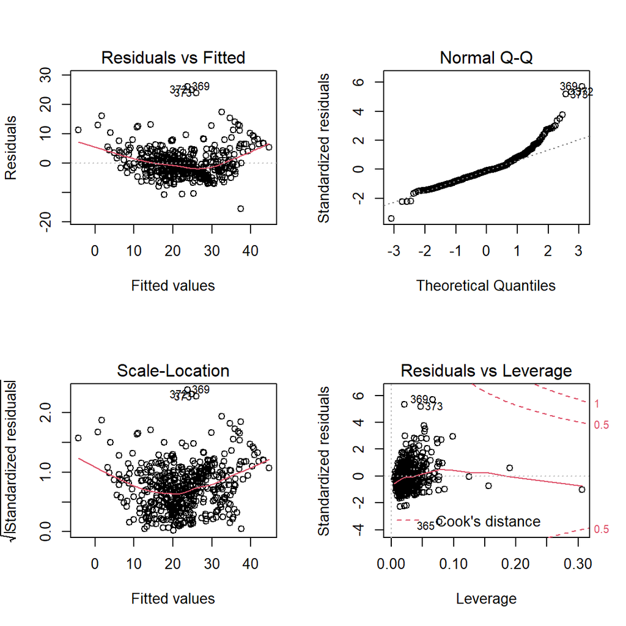

```r
par(mfrow=c(2,2))
plot(lmfit)
```

- **Residual plot이 추세를 가지고 있음**
- **선형회귀모형의 가정에 위배됨을 확인**

**2) 잔차의 정규성 가정을 만족하기 위한 변수 변환작업 수행**

- MEDV 분포 변환
  - Linear model은 예측문제에 적합하지만, 적용에 있어 몇 가지 가정이 존재
  - 그 중 모형의 잔차 $y-\hat y = \epsilon$ 의 정규분포 가정을 만족하기 위한 타겟변수 MEDV의 분포변환
  - sqrt 변환 / log 변환 / boxcox 변환 수행

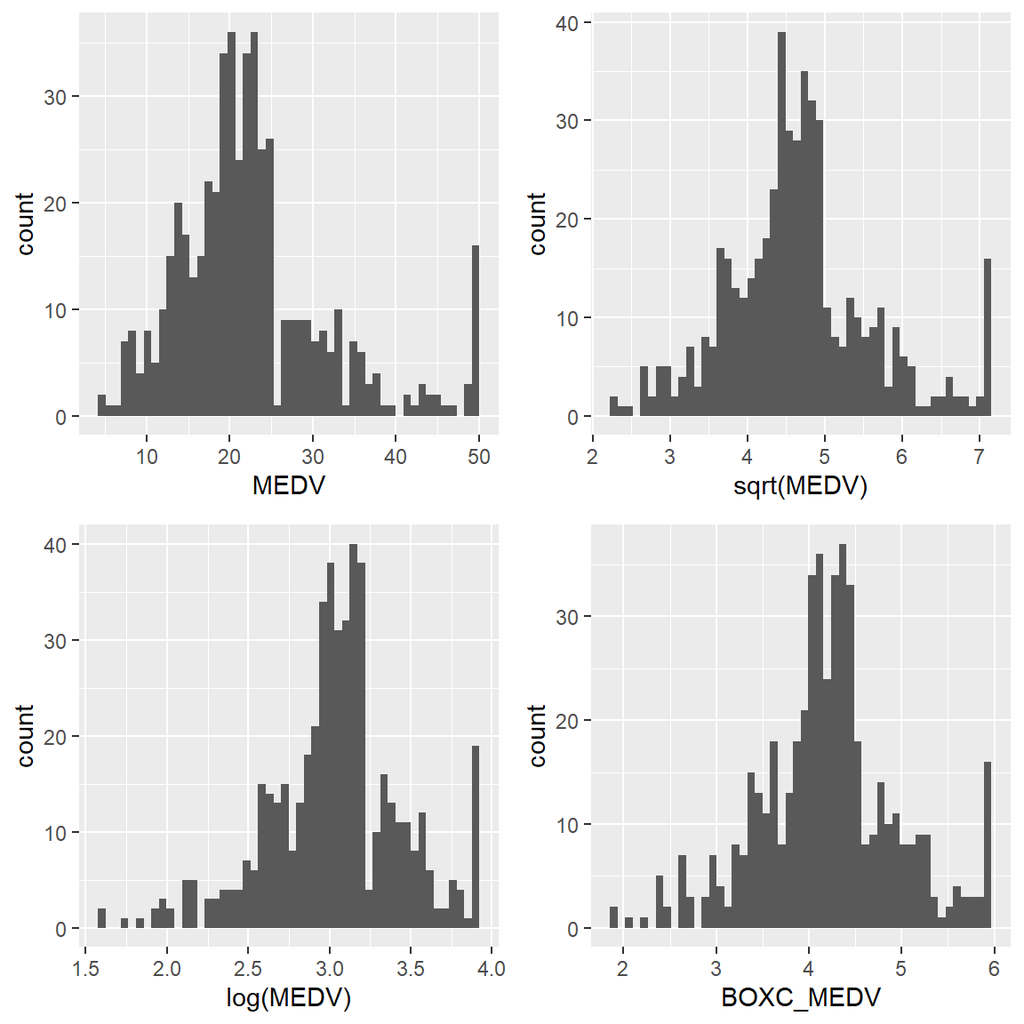

```r
library(ggplot2)
library(gridExtra)
library(MASS)

f = ggplot(boston_raw,aes(x=MEDV)) + geom_histogram(bins=50)
#sqrt(y)
a=ggplot(boston_raw,aes(x=sqrt(MEDV))) + geom_histogram(bins=50)

#log(y)
b=ggplot(boston_raw,aes(x=log(MEDV))) + geom_histogram(bins=50)

#boxcox(y)
boston_raw_bc <- boston_raw
box_df <- boxcox(boston_raw_bc$MEDV~1, plotit=F)
lam <- box_df$x[which.max(box_df$y)]
boston_raw_bc$BOXC_MEDV <- (boston_raw_bc$MEDV^lam-1)/lam
c=ggplot(boston_raw_bc,aes(x=BOXC_MEDV)) + geom_histogram(bins=50)
grid.arrange(f,a,b,c, heights= c(0.5,0.5))
```

- *세 변환간에 유의한 차이점이 없어보여 sqrt변환 결정*

**3) 변수 간 다중공선성(Multicolinearity 체크)**

```r
#VIF < 10
library(car)
lm.bfit <- lm(MEDV ~., data=boston_raw)
sort(vif(lm.bfit))
```

```
##     CHAS    B1000     CRIM  PTRATIO       RM       ZN    LSTAT      AGE
## 1.073995 1.348521 1.792192 1.799084 1.933744 2.298758 2.941491 3.100826
##      DIS    INDUS      NOX      RAD      TAX
## 3.955945 3.991596 4.393720 7.484496 9.008554
```

- *독립변수간 VIF<10 이므로 제외되는 독립변수는 없는것으로 결정*

**4) 각 독립변수 간 대다수 상관관계가 존재하여 상호작용항 고려**

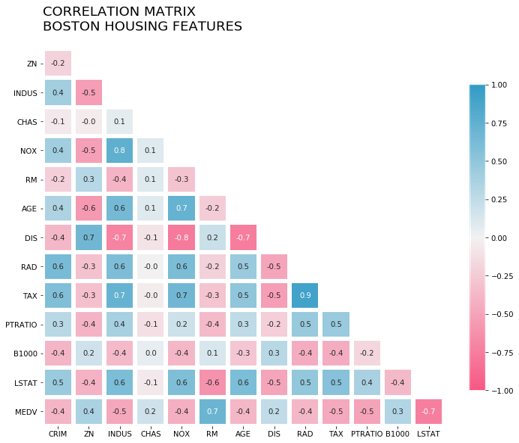

**5) LSTAT 및 RM의 경우 quadratic 관계 고려**

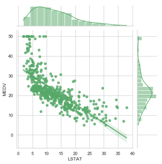

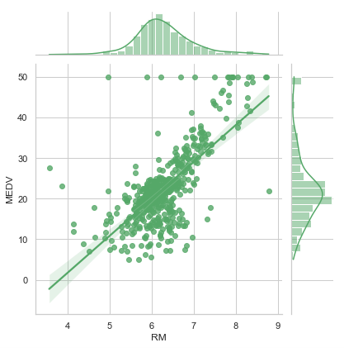

- **최종적으로 다음 formula를 선형모형으로 적합**
  - 기존 독립변수 및 제곱항, 상호작용항 고려시 120개의 변수 생성

```r
lmfit <- lm(sqrt(MEDV)~(.+I(LSTAT^2) + I(RM^2))^2, data=boston_raw)
lmfit$call
```

```
## lm(formula = sqrt(MEDV) ~ (. + I(LSTAT^2) + I(RM^2))^2, data = boston_raw)
```

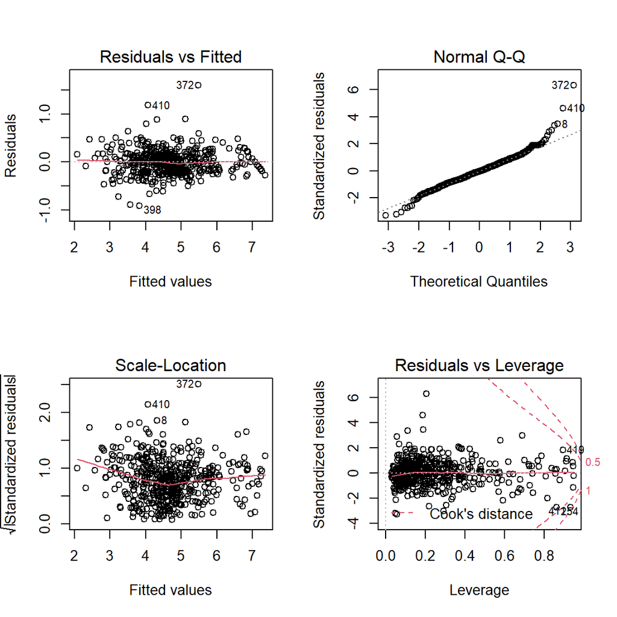

```r
par(mfrow=c(2,2))
plot(lmfit)
```

## 5. 최적 모형 탐색

- *Stepwise selection 방법으로 변수 선택*
- *RSS, Adjusted R^2, Mallows’CP, BIC 기준의 변수 선택*
- *leaps 라이브러리의 regsubsets 함수이용*

```r
library(leaps)
library(caret)

# #boston_scale_ <- preProcess(boston_[1:13], method = c("range"))
# boston_scale_ <- preProcess(boston_[1:13], method = c("center", "scale"))
# boston_sc <- predict(boston_scale_, boston_[1:13])
# boston_ <- data.frame(cbind(boston_sc, boston_$MEDV))
# colnames(boston_) <- c("CRIM", "ZN", "INDUS", "CHAS", "NOX", "RM", "AGE", "DIS", "RAD", "TAX", "PTRATIO", "B1000", "LSTAT", "MEDV")
# knitr::kable(head(boston_, 10),digit=2)
#
# #boston_test_scale_ <- preProcess(boston_test[1:13], method = c("range"))
# boston_test_scale_ <- preProcess(boston_test[1:13], method = c("center", "scale"))
# boston_test_sc <- predict(boston_test_scale_, boston_test[1:13])
# boston_test <- data.frame(cbind(boston_test_sc, boston_test$MEDV))
# colnames(boston_test) <- c("CRIM", "ZN", "INDUS", "CHAS", "NOX", "RM", "AGE", "DIS", "RAD", "TAX", "PTRATIO", "B1000", "LSTAT", "MEDV")
# knitr::kable(head(boston_test, 10),digit=2)
```

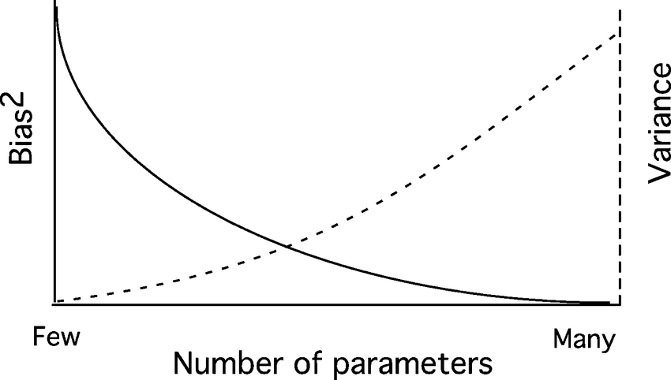

- *Stepwise selection 수행*
  - 모형 개발 시 모형의 Parameter 수가 많을수록 Bias는 감소하지만 모형의 Variance가 증가하기때문에 적정 수준에서 Parameter를 제어해줄 필요성이 있음
  - Stepwise variable selection을 활용, RSS, Adjusted R2, Mallow’s CP, BIC 기준으로 최적 변수 조합 선택

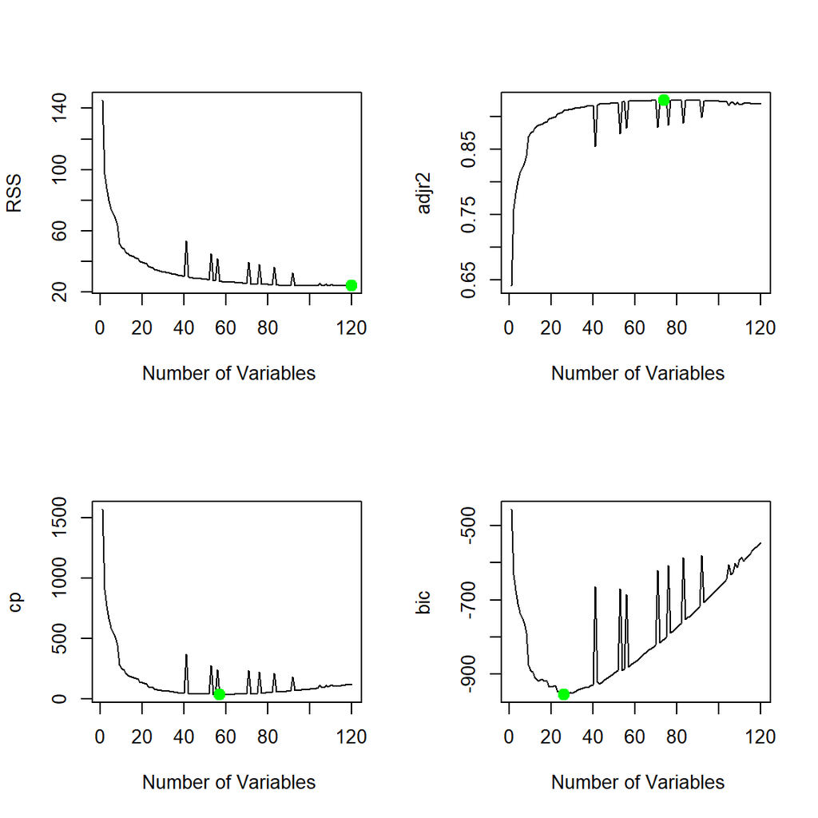

```r
library(leaps)
#Stepwise feature selection : RSS, Adjusted R^2, Mallows' CP, BIC(Bayesian Information Criterion)
regfit.stw=regsubsets(sqrt(MEDV)~(.+I(LSTAT^2) + I(RM^2))^2 , data=boston_ , nvmax=length(lmfit$coefficients)-1, method ="seqrep")
sum.stw=summary(regfit.stw)
par(mfrow=c(2,2))

plot(sum.stw$rss, xlab=" Number of Variables", ylab="RSS", type="l")
nrss<-which.min(sum.stw$rss)
points(nrss, sum.stw$rss[nrss], col ="green", cex =2, pch =20)

plot(sum.stw$adjr2, xlab=" Number of Variables", ylab="adjr2", type="l")
nadjr2<-which.max(sum.stw$adjr2)
points (nadjr2, sum.stw$adjr2[nadjr2], col ="green", cex =2, pch =20)

plot(sum.stw$cp, xlab=" Number of Variables", ylab="cp", type="l")
ncp<-which.min(sum.stw$cp)
points (ncp, sum.stw$cp[ncp], col ="green", cex =2, pch =20)

plot(sum.stw$bic, xlab=" Number of Variables", ylab="bic", type="l")
nbic<-which.min(sum.stw$bic)
points (nbic, sum.stw$bic[nbic], col ="green", cex =2, pch =20)
```

```r
cat("Variable selection by RSS :", nrss, '\n')
```

```
## Variable selection by RSS : 120
```

```r
cat("Variable selection by Adjusted R2 :", nadjr2, '\n')
```

```
## Variable selection by Adjusted R2 : 74
```

```r
cat("Variable selection by Mallow's CP :", ncp, '\n')
```

```
## Variable selection by Mallow's CP : 57
```

```r
cat("Variable selection by BIC :", nbic, '\n')
```

```
## Variable selection by BIC : 26
```

## 6. 모형 검증

- 모형 선택을 위한 성능평가
  1. Leave One Out Cross Validation (LOOCV) : 개별 데이터 모두를 검증 데이터로 활용
  2. K-fold Cross Validation : k개의 랜덤한 집합을 생성 후 각 partition을 모두 검증 데이터로 활용

*1) LOOCV 수행*

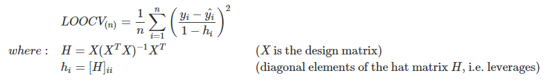

```r
#Regsubset lm formulas
leaps <- regsubsets(sqrt(MEDV)~(.+I(LSTAT^2) + I(RM^2))^2 , data=boston_ , nvmax=length(lmfit$coefficients)-1, method ="seqrep")
reg_ids <- summary(leaps)$which ## 추가
xvars <- dimnames(reg_ids)[[2]][-1]  ## column names (all covariates except intercept)
responsevar <- 'sqrt(MEDV)'  ## name of response


lst <- vector("list", length(lmfit$coefficients)-1)  ## set up an empty model list
h <- vector("list", length(lmfit$coefficients)-1)


for (i in 1:dim(reg_ids)[1]) {

     id <- reg_ids[i, ]
     # xvars는 변수조합을 가진 벡터, regsubset이 산출한 모형의 객체를 찾아가 객체가 사용한 변수를 찾음
     form <- reformulate(xvars[which(id[-1])], response=responsevar, id[1])
     lst[[i]] <- lm(form, data=boston_)

     MF <- model.frame(formula = form , data=boston_)
     MT <- attr(x = MF, which = "terms")
     mod1 <- lm(form, data=boston_)
     X <- model.matrix(object = MT, data = mod1$model)

     H=X%*%solve(t(X)%*%X, tol = 1e-20)%*%t(X) #singular torlerance
     h[[i]]=diag(H)
}

## FIND LOOCV error
loocv_rss_stw <- mean((lst[[nrss]]$residuals /(1-h[[nrss]]))^2)
loocv_adjr2_stw <- mean((lst[[nadjr2]]$residuals /(1-h[[nadjr2]]))^2)
loocv_cp_stw <- mean((lst[[ncp]]$residuals /(1-h[[ncp]]))^2)
loocv_bic_stw <- mean((lst[[nbic]]$residuals /(1-h[[nbic]]))^2)

# #sqrt(MEDV) for responsevar text
# boston_c <- data.frame(cbind(boston_, sqrt(boston_$MEDV)))
# colnames(boston_c) <- c("CRIM", "ZN", "INDUS", "CHAS", "NOX", "RM", "AGE", "DIS", "RAD", "TAX", "PTRATIO", "B1000", "LSTAT", "MEDV","sqrt(MEDV)")
# boston_c <- boston_c[,-14]
```

- *회귀모형 object에 대한 설계행렬(Design matrix) 생성*
  - 설계행렬(Design matrix)을 구성하여 예측모형 함수 생성 (NxP, N : 관측치, P : 예측변수)
  - model.frame을 통해 regsubset을 통해 만들어지는 각 변수조합의 회귀모형에 대한 모형행렬 생성
  - model.frame은 각 모형에 포함된 변수조합으로 reformulate된 수식을 받아 model.matrix에 전달하여 설계행렬을 생성
  - 이때, attr함수를 통해 모형의 특성(terms)를 함께 묶어서 전달
- *LOOCV 수행*
  - 각 모형의 설계행렬을 통해 LOOCV 수행
  - Hat Matrix의 대각원소 h는 i번째 관측치가 X-space의 중심점으로부터 얼마나 이탈되어있는지를 나타내는 influence factor임
  - 각 모형과 influence factor h를 list형식으로 저장하여 각 모형에서 LOOCV를 계산할 수 있도록 함
  - **Hat matrix대신 for문 형식으로도 구현할 수 있지만 Hat Matrix 방식의 계산은 계산시간이 크게 단축된다는 점에서 유리함**

```r
cat("LOOCV error for rss : ", loocv_rss_stw)
```

```
## LOOCV error for rss :  0.1724381
```

```r
cat("LOOCV error for adjr2 : ", loocv_adjr2_stw)
```

```
## LOOCV error for adjr2 :  0.114247
```

```r
cat("LOOCV error for cp : ", loocv_cp_stw)
```

```
## LOOCV error for cp :  0.09470624
```

```r
cat("LOOCV error for bic : ", loocv_bic_stw)
```

```
## LOOCV error for bic :  0.09126004
```

- *LOOCV결과 BIC기준의 MSE가 가장 낮게 책정됨*

*2) 10-fold Cross Validation 수행*

- *regsubset으로 생성되는 모형에 대한 예측함수 정의*
- for문 방식으로 Cross Validation 실행시 필요
- 기존 regsubset에는 prediction 함수가 정의되어있지 않음
- 각 모형별 Cross Validation 수행 후 MSE를 계산
- 회귀모형 object와 regsubset 수행 수 산출되는 id값을 받아 Validation 데이터에 대한 예측값 생성

```r
library(leaps)
#define predict regsubsets
predict.regsubsets = function(object, newdata, id, ...){
  form = as.formula(object$call[[2]])
  mat = model.matrix(form, newdata)
  coefi = coef(object, id=id)
  xvars = names(coefi)
  mat[,xvars]%*% coefi
}
```

- *10-fold Cross Validation 수행*

```r
## 10-fold Cross validation
k=10
set.seed(1)
folds = sample(1:k, nrow(boston_), replace=T)
cv.errors = matrix(0,k,120)
for(j in 1:k){
  leaps_ <- regsubsets(sqrt(MEDV)~(.+I(LSTAT^2) + I(RM^2))^2 , data=boston_[folds!=j,] , nvmax=length(lmfit$coefficients)-1, method ="seqrep")
    for(l in c(nrss,nadjr2, ncp, nbic)){
        pred = predict(leaps_,id=l,boston_[folds==j,])
        cv.errors[j,l] = mean((sqrt(boston_$MEDV[folds==j]) - pred )^2)
    }
}
cvs <- cv.errors[,c(nrss,nadjr2,ncp,nbic)]
colnames(cvs) <- c("RSS","ADJR2","CP","BIC")
cvs
```

```
##             RSS     ADJR2         CP        BIC
##  [1,] 0.3911455 0.3652035 0.23718194 0.48416986
##  [2,] 0.1367396 0.1519071 0.13740201 0.09862582
##  [3,] 0.2146507 0.2898987 0.15135271 0.14660524
##  [4,] 0.1299244 0.1394722 0.13749513 0.10405570
##  [5,] 0.1812465 0.2313115 0.15281742 0.13743265
##  [6,] 0.1375106 0.1295782 0.12190668 0.13213906
##  [7,] 0.0881582 0.1770421 0.05894058 0.08366653
##  [8,] 0.2217779 0.2023453 0.18811235 0.17228514
##  [9,] 0.1659681 0.1698176 0.10686246 0.07986378
## [10,] 0.2760749 0.3941757 0.37343549 0.18092756
```

```r
mean.cv.errors = apply(cvs, 2, mean)
mean.cv.errors
```

```
##       RSS     ADJR2        CP       BIC
## 0.1943197 0.2250752 0.1665507 0.1619771
```

```r
cv_n <- which.min(mean.cv.errors)
cv_n
```

```
## BIC
##   4
```

- *10-fold cross validation 결과 BIC 기준의 MSE가 가장 낮게 책정됨*
- *LOOCV와 10-fold CV 모두 BIC 기준의 모형의 성능이 가장 우수함*

## 7. 모형 진단 및 성능 테스트

```r
#simple multiple linear regression
blm.fit <- lm(MEDV~., boston_)
pred_blm <- predict(blm.fit, boston_test)
blm.loss <- mean((pred_blm - boston_test$MEDV)^2)
cat("test MSE basic Linear model :",blm.loss)
```

```
## test MSE basic Linear model : 17.57527
```

```r
#cat("test MSE Stepwise - BIC:" ,mean((sqrt(boston_test$MEDV) - predict(regfit.stw, id=nbic, boston_test))^2),"\n")
cat("test MSE Stepwise - BIC model :" ,mean( (boston_test$MEDV - predict(regfit.stw, id=nbic, boston_test)^2)^2 ),"\n")
```

```
## test MSE Stepwise - BIC model : 14.04123
```

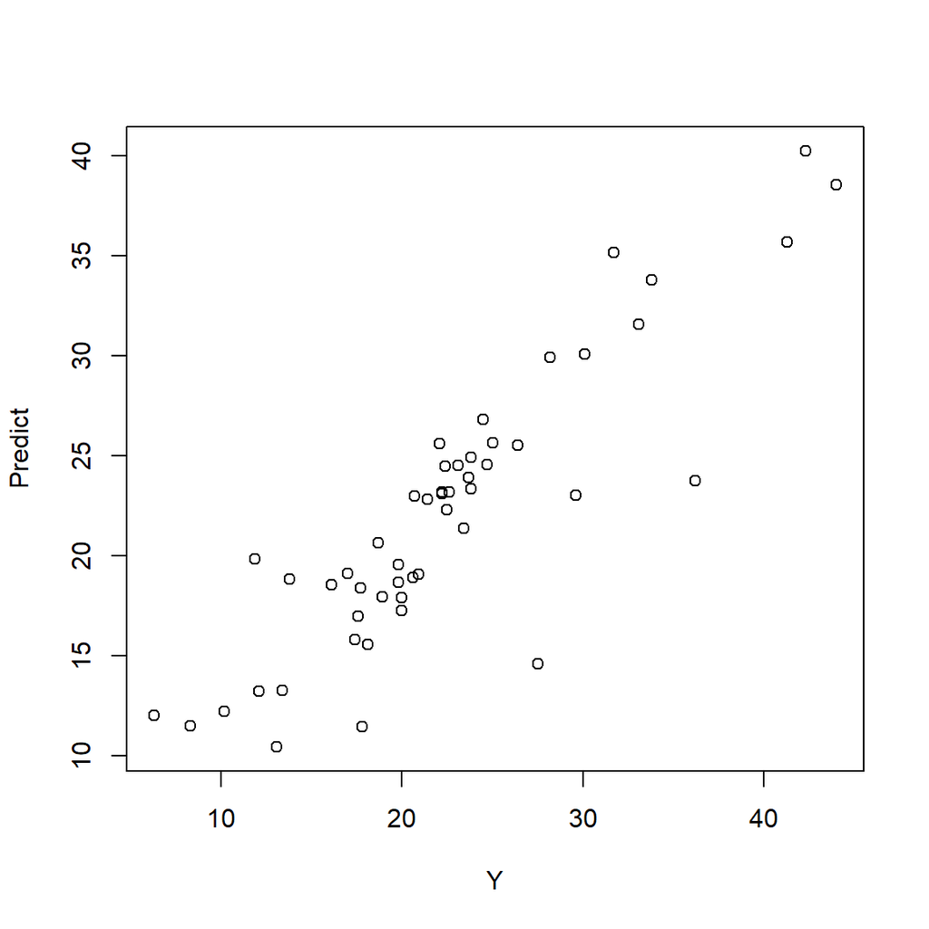

```r
plot(boston_test$MEDV, predict(regfit.stw, id=nbic, boston_test)^2,xlab="Y", ylab="Predict")
```

- *STEPWISE - BIC 모형의 TEST MSE는 약 14.04로서 기본모형 MSE 17.57보다 약 25%정도의 성능향상이 있었음*

```r
summary(lst[[nbic]])
```

```
##
## Call:
## lm(formula = form, data = boston_)
##
## Residuals:
##      Min       1Q   Median       3Q      Max
## -0.93823 -0.16975 -0.01028  0.15507  1.66577
##
## Coefficients:
##                  Estimate Std. Error t value Pr(>|t|)
## (Intercept)     2.271e+01  6.273e+00   3.620 0.000329 ***
## RM             -1.081e+01  2.443e+00  -4.427 1.21e-05 ***
## AGE             8.888e-02  1.206e-02   7.370 8.89e-13 ***
## TAX            -2.003e-02  6.372e-03  -3.144 0.001785 **
## B1000           8.452e-03  1.253e-03   6.743 5.04e-11 ***
## LSTAT           1.851e-01  2.613e-02   7.084 5.78e-12 ***
## I(RM^2)         1.519e+00  3.196e-01   4.751 2.77e-06 ***
## CRIM:CHAS       8.133e-02  1.817e-02   4.475 9.80e-06 ***
## CRIM:NOX       -7.550e-02  1.373e-02  -5.500 6.53e-08 ***
## I(RM^2):CRIM    8.144e-04  2.366e-04   3.442 0.000635 ***
## INDUS:DIS      -9.854e-03  2.086e-03  -4.724 3.14e-06 ***
## I(RM^2):INDUS   9.218e-04  1.851e-04   4.981 9.19e-07 ***
## AGE:NOX        -3.601e-02  6.571e-03  -5.480 7.29e-08 ***
## I(RM^2):NOX     4.452e-02  1.572e-02   2.832 0.004844 **
## RM:AGE         -5.022e-03  1.249e-03  -4.021 6.85e-05 ***
## RM:TAX          9.638e-03  1.879e-03   5.129 4.43e-07 ***
## RM:I(RM^2)     -5.792e-02  1.430e-02  -4.050 6.09e-05 ***
## AGE:RAD         4.140e-04  4.904e-05   8.441 4.92e-16 ***
## AGE:PTRATIO    -8.831e-04  1.116e-04  -7.911 2.20e-14 ***
## AGE:B1000      -7.436e-05  1.501e-05  -4.954 1.05e-06 ***
## AGE:I(LSTAT^2) -1.733e-05  3.950e-06  -4.386 1.46e-05 ***
## TAX:DIS        -1.169e-04  4.610e-05  -2.535 0.011606 *
## TAX:LSTAT      -4.544e-04  3.952e-05 -11.498  < 2e-16 ***
## TAX:I(LSTAT^2)  6.734e-06  1.071e-06   6.287 8.01e-10 ***
## TAX:I(RM^2)    -9.315e-04  1.403e-04  -6.640 9.56e-11 ***
## B1000:LSTAT    -6.858e-05  3.055e-05  -2.245 0.025302 *
## LSTAT:I(RM^2)  -1.860e-03  4.565e-04  -4.075 5.49e-05 ***
## ---
## Signif. codes:  0 '***' 0.001 '**' 0.01 '*' 0.05 '.' 0.1 ' ' 1
##
## Residual standard error: 0.2842 on 428 degrees of freedom
## Multiple R-squared:  0.9149, Adjusted R-squared:  0.9097
## F-statistic:   177 on 26 and 428 DF,  p-value: < 2.2e-16
```

```r
sort(lst[[nbic]]$coefficients)
```

```
##             RM       CRIM:NOX     RM:I(RM^2)        AGE:NOX            TAX
##  -1.081346e+01  -7.549611e-02  -5.792133e-02  -3.600636e-02  -2.003044e-02
##      INDUS:DIS         RM:AGE  LSTAT:I(RM^2)    TAX:I(RM^2)    AGE:PTRATIO
##  -9.854057e-03  -5.021994e-03  -1.860228e-03  -9.315138e-04  -8.831347e-04
##      TAX:LSTAT        TAX:DIS      AGE:B1000    B1000:LSTAT AGE:I(LSTAT^2)
##  -4.544376e-04  -1.168523e-04  -7.436168e-05  -6.858328e-05  -1.732474e-05
## TAX:I(LSTAT^2)        AGE:RAD   I(RM^2):CRIM  I(RM^2):INDUS          B1000
##   6.734120e-06   4.139765e-04   8.143611e-04   9.217805e-04   8.451936e-03
##         RM:TAX    I(RM^2):NOX      CRIM:CHAS            AGE          LSTAT
##   9.637671e-03   4.452390e-02   8.133191e-02   8.887804e-02   1.851041e-01
##        I(RM^2)    (Intercept)
##   1.518501e+00   2.271055e+01
```

- *모형은 변수 기존변수, 교호항 및 제곱항을 포함한 26개 변수로 이루어져있음*

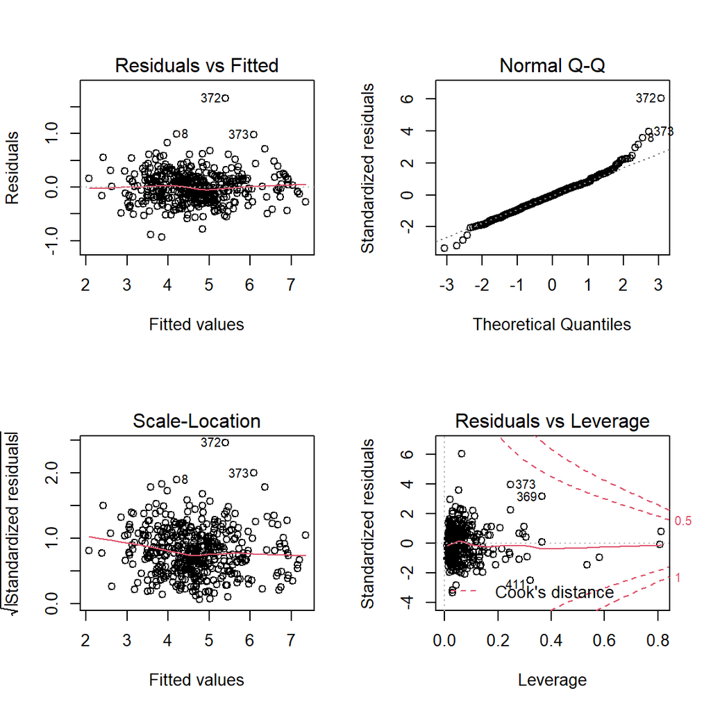

```r
par(mfrow=c(2,2))
plot(lst[[nbic]])
```

```r
ks.test(lst[[nbic]]$residuals, "pnorm", mean= mean(lst[[nbic]]$residuals), sd = sd(lst[[nbic]]$residuals))
```

```
##
##  One-sample Kolmogorov-Smirnov test
##
## data:  lst[[nbic]]$residuals
## D = 0.054915, p-value = 0.1286
## alternative hypothesis: two-sided
```

- *Residual plot, qqplot, scatter plot, cook’s distance 등을 고려해봤을때, 해당 선형모형으로의 적합이 나쁘지 않은것으로 판단됨*
- *개발된 모형에서 다중공선성 등의 문제점이 있을 수 있으나 예측모형 개발이 목적이기 때문에, 주요한 관심사로 두지 않음*
- *다양한 변수변환(log변환, boxcox변환)과 변수 스케일링 등을 통해 다양한 경우의 수를 고려하여 모형 고도화 필요함*
- *예측력 향상을 위해 다른 모형을 고려할 필요성 있음(Regularization, Bagging, Boosting, SVR, NeuralNetwork 등)*

## 8. 모형 별 예측성능 비교

| Model | MSE | Rank |
| --- | --- | --- |
| GBM | 10.304 | 1 |
| RIDGE | 12.338 | 2 |
| RandomForest | 13.083 | 3 |
| LASSO | 13.319 | 4 |
| Linear Regression(Stepwise-BIC) | 14.041 | 5 |
| Linear Regression(BASIC) | 17.575 | 6 |
| Decision Tree | 27.605 | 7 |

- **예측성능 비교결과 Stepwise-BIC 모형은 비교 모형 중 5등으로 예측성능이 비교적 떨어짐**
- **예측성능 기준으로 Gradient Boosting Machine(GBM)이 가장 성능이 뛰어남**

*모형 별 상세내역*

*1) RIDGE / LASSO*

- *Ridge regression (L2 norm regularization)*

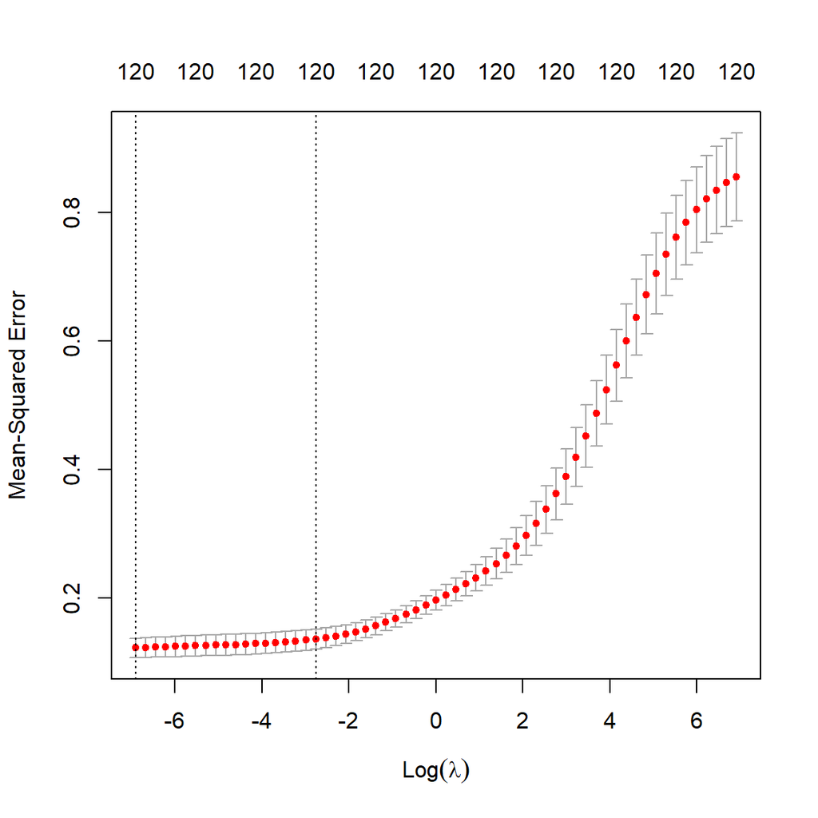

```r
#Ridge
library(glmnet)
library(tidyverse)

# Model Matrix for Training dataset
MF_t <- model.frame(formula = sqrt(MEDV)~(.+I(LSTAT^2) + I(RM^2))^2 , data=boston_)
MT_t <- attr(x = MF_t, which = "terms")
mod1_t <- lm(sqrt(MEDV)~(.+I(LSTAT^2) + I(RM^2))^2, data=boston_)
X <- model.matrix(object = MT_t, data = mod1_t$model)

# Model Matrix for Test dataset
MF_e <- model.frame(formula = sqrt(MEDV)~(.+I(LSTAT^2) + I(RM^2))^2 , data=boston_test)
MT_e <- attr(x = MF_e, which = "terms")
mod1_e <- lm(sqrt(MEDV)~(.+I(LSTAT^2) + I(RM^2))^2, data=boston_test)
X_e <- model.matrix(object = MT_e, data = mod1_e$model)

x=X[,-1]
x_test=X_e[,-1]
y=sqrt(boston_$MEDV)
y_test=sqrt(boston_test$MEDV)

lambdas = 10^seq(3, -3, by = -.1)
cv.out=cv.glmnet(x, y, alpha=0, nfolds=10, lambda=lambdas)
plot(cv.out)
```

```r
lambda_opt=cv.out$lambda.min
ridge_mod = glmnet(x,y,alpha=0,lambda = lambda_opt)


ridge_pred =  predict(ridge_mod,s=lambda_opt,newx= x_test)
coef_ridge = predict(ridge_mod,type="coefficients",s=lambda_opt )
mse_ridge = mean((ridge_pred^2 - y_test^2)^2) # Calculate test MSE
#coef_ridge
cat("test MSE Ridge:" ,mse_ridge)
```

```
## test MSE Ridge: 12.33892
```

- *LASSO regression (L1 norm regularization)*

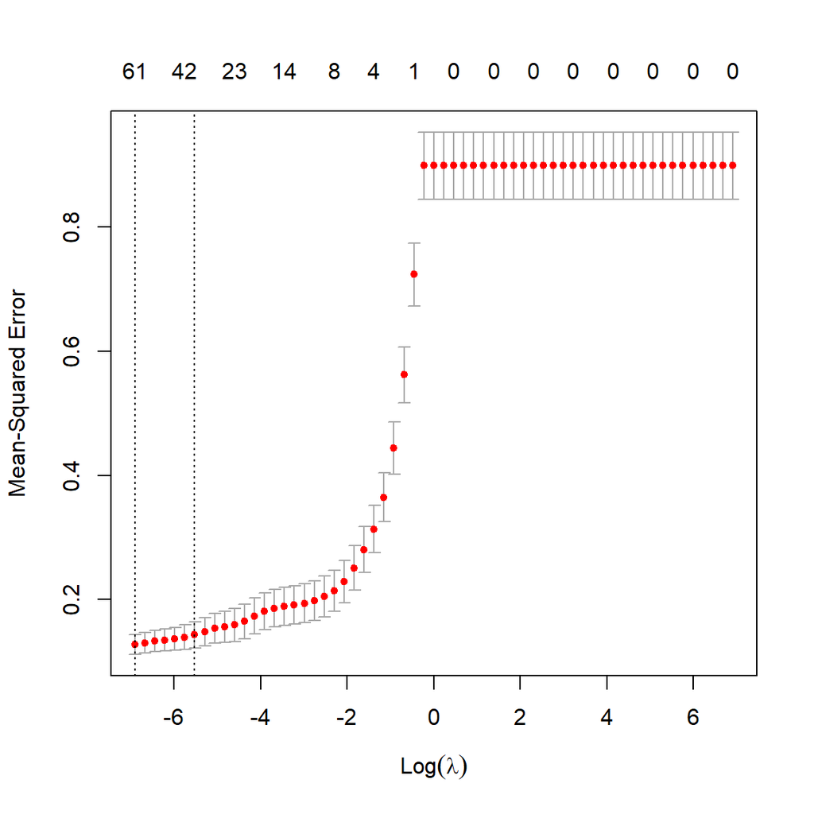

```r
#LASSO
library(glmnet)
library(tidyverse)

# Model Matrix for Training dataset
MF_t <- model.frame(formula = sqrt(MEDV)~(.+I(LSTAT^2) + I(RM^2))^2 , data=boston_)
MT_t <- attr(x = MF_t, which = "terms")
mod1_t <- lm(sqrt(MEDV)~(.+I(LSTAT^2) + I(RM^2))^2, data=boston_)
X <- model.matrix(object = MT_t, data = mod1_t$model)

# Model Matrix for Test dataset
MF_e <- model.frame(formula = sqrt(MEDV)~(.+I(LSTAT^2) + I(RM^2))^2 , data=boston_test)
MT_e <- attr(x = MF_e, which = "terms")
mod1_e <- lm(sqrt(MEDV)~(.+I(LSTAT^2) + I(RM^2))^2, data=boston_test)
X_e <- model.matrix(object = MT_e, data = mod1_e$model)

x=X[,-1]
x_test=X_e[,-1]
y=sqrt(boston_$MEDV)
y_test=sqrt(boston_test$MEDV)

lambdas = 10^seq(3, -3, by = -.1)
cv.out=cv.glmnet(x, y, alpha=1, nfolds=10, lambda=lambdas)
plot(cv.out)
```

```r
lambda_opt=cv.out$lambda.min
lasso_mod = glmnet(x,y,alpha=1,lambda = lambda_opt)


lasso_pred =  predict(lasso_mod,s=lambda_opt,newx= x_test)
coef_lasso = predict(lasso_mod,type="coefficients",s=lambda_opt )
mse_lasso = mean((lasso_pred^2 - y_test^2)^2) # Calculate test MSE
cat("test MSE LASSO:" ,mse_lasso)
```

```
## test MSE LASSO: 13.31907
```

*3) Decision Tree*

```r
library(tree)
tree.boston <- tree(MEDV ~.,data=boston_)
summary(tree.boston)
```

```
##
## Regression tree:
## tree(formula = MEDV ~ ., data = boston_)
## Variables actually used in tree construction:
## [1] "RM"      "LSTAT"   "DIS"     "CRIM"    "PTRATIO"
## Number of terminal nodes:  8
## Residual mean deviance:  12.95 = 5789 / 447
## Distribution of residuals:
##     Min.  1st Qu.   Median     Mean  3rd Qu.     Max.
## -17.8000  -2.0270   0.1733   0.0000   2.2290  17.2000
```

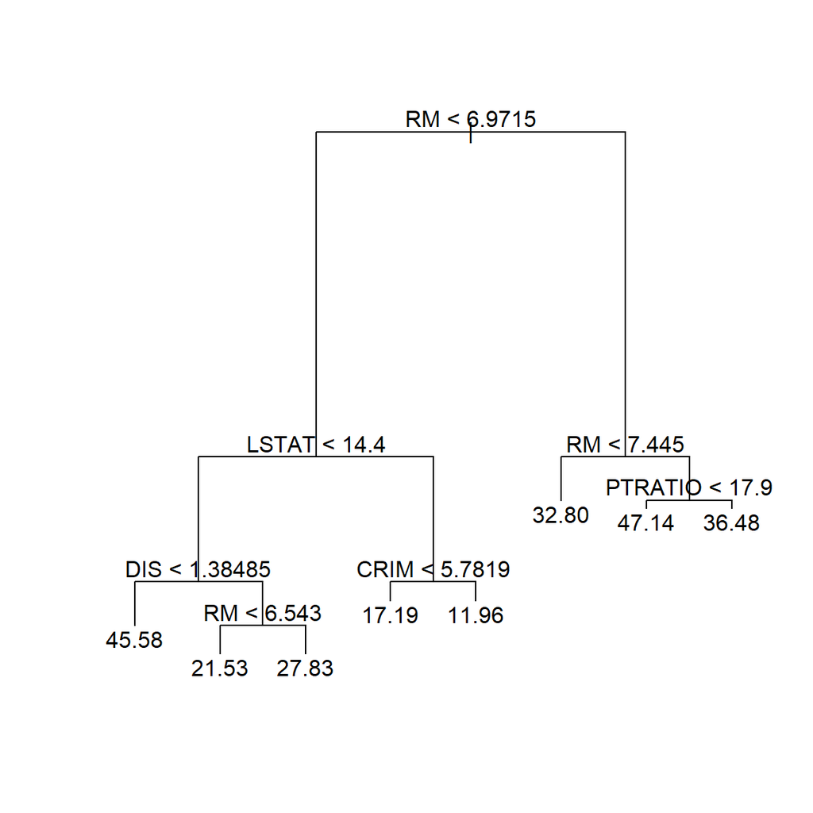

```r
plot(tree.boston)
text(tree.boston, pretty = 0)
```

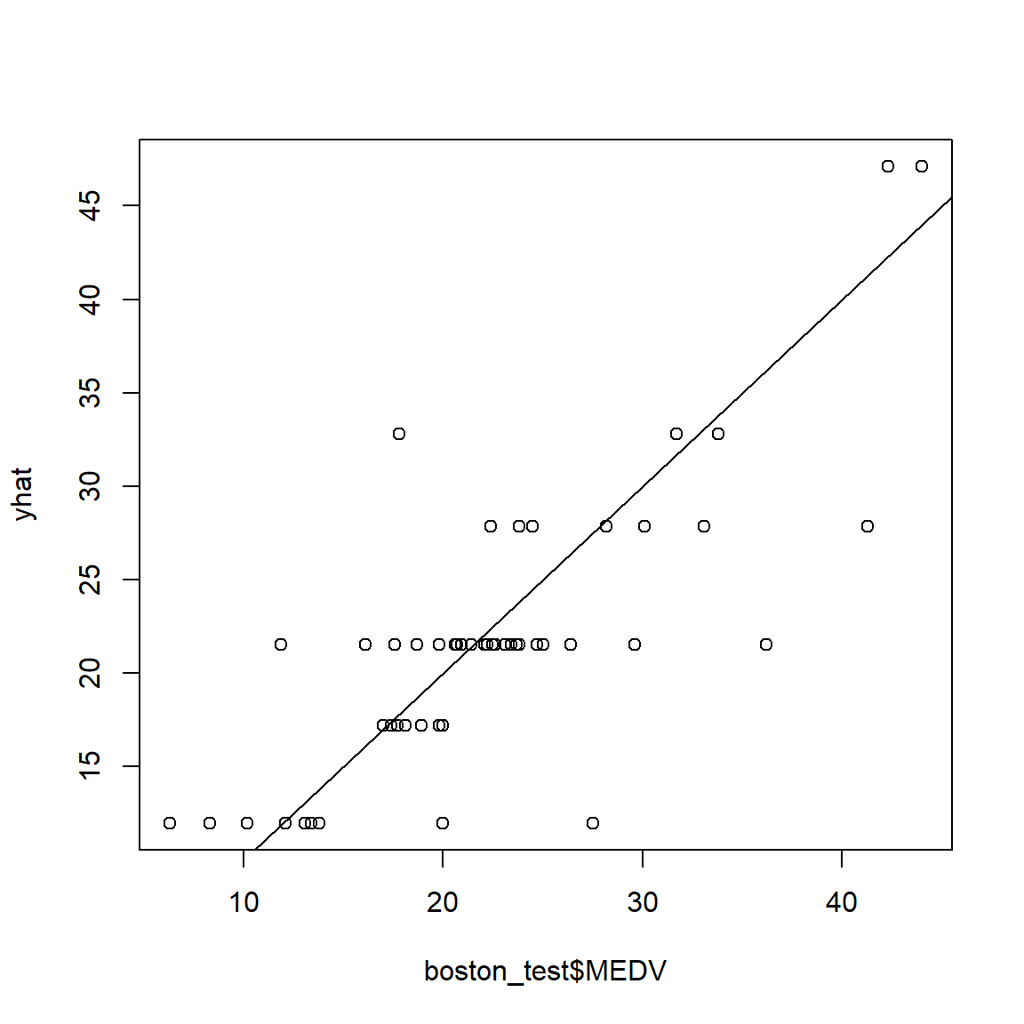

```r
yhat <- predict(tree.boston, newdata = boston_test)
plot(boston_test$MEDV, yhat)
abline(0, 1)
```

```r
mean((yhat - boston_test$MEDV)^2)
```

```
## [1] 27.60514
```

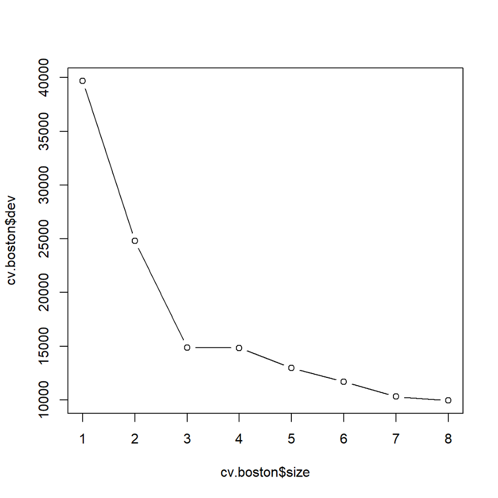

```r
#cross validation
cv.boston = cv.tree(tree.boston)
plot(cv.boston$size, cv.boston$dev, type="b")
```

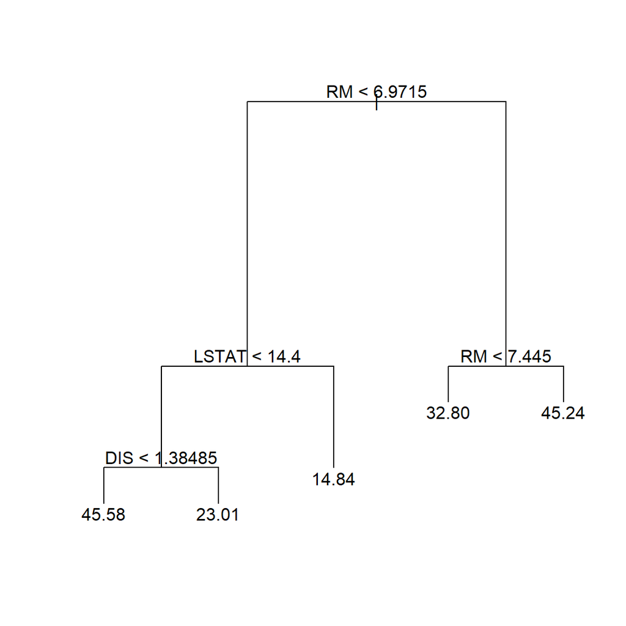

```r
prune.boston = prune.tree(tree.boston, best=5)
plot(prune.boston)
text(prune.boston,pretty=0)
```

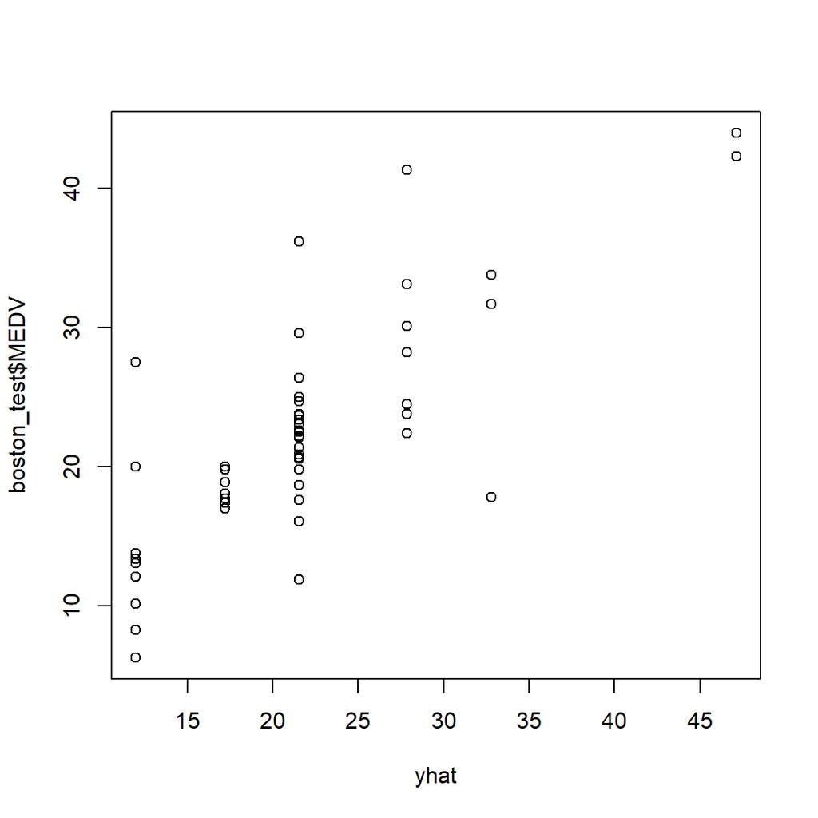

```r
#prediction
yhat=predict(tree.boston, newdata=boston_test)
plot(yhat, boston_test$MEDV)
```

```r
mean((yhat-boston_test$MEDV)^2)
```

```
## [1] 27.60514
```

*4) Random Forest*

```r
library(randomForest)
library(caret)
#Cross validation
fitControl <- trainControl(method = "repeatedcv", number = 10, repeats = 5)
rf_fit <- train(MEDV ~ ., data = boston_, method = "rf", trControl = fitControl, verbose = F)
rf_fit
```

```
## Random Forest
##
## 455 samples
##  13 predictor
##
## No pre-processing
## Resampling: Cross-Validated (10 fold, repeated 5 times)
## Summary of sample sizes: 410, 410, 411, 409, 409, 409, ...
## Resampling results across tuning parameters:
##
##   mtry  RMSE      Rsquared   MAE
##    2    3.474119  0.8718150  2.378308
##    7    3.121607  0.8880247  2.149848
##   13    3.237832  0.8769672  2.213959
##
## RMSE was used to select the optimal model using the smallest value.
## The final value used for the model was mtry = 7.
```

```r
set.seed(1)
bag.boston = randomForest(MEDV~., data=boston_, mtry=7, importance=TRUE)
bag.boston
```

```
##
## Call:
##  randomForest(formula = MEDV ~ ., data = boston_, mtry = 7, importance = TRUE)
##                Type of random forest: regression
##                      Number of trees: 500
## No. of variables tried at each split: 7
##
##           Mean of squared residuals: 10.00216
##                     % Var explained: 88.47
```

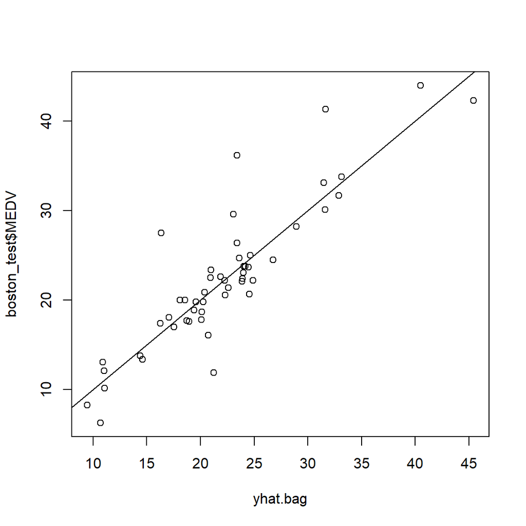

```r
yhat.bag = predict(bag.boston, newdata=boston_test)
plot(yhat.bag, boston_test$MEDV)
abline(0,1)
```

```r
mean((yhat.bag-boston_test$MEDV)^2)
```

```
## [1] 13.083
```

```r
#variance importance
importance(bag.boston)
```

```
##            %IncMSE IncNodePurity
## CRIM    16.7525186    1893.53250
## ZN       2.5925959      69.61939
## INDUS    9.7121283    1265.53369
## CHAS     0.7121444      85.81638
## NOX     16.9139256    1712.89342
## RM      41.7434009   14037.94164
## AGE     11.4920345     737.72056
## DIS     22.2075872    2363.98219
## RAD      4.9794941     202.95625
## TAX     11.9343552     512.19605
## PTRATIO 14.3439775    1441.67902
## B1000    9.0335488     554.30423
## LSTAT   36.1594342   14087.44223
```

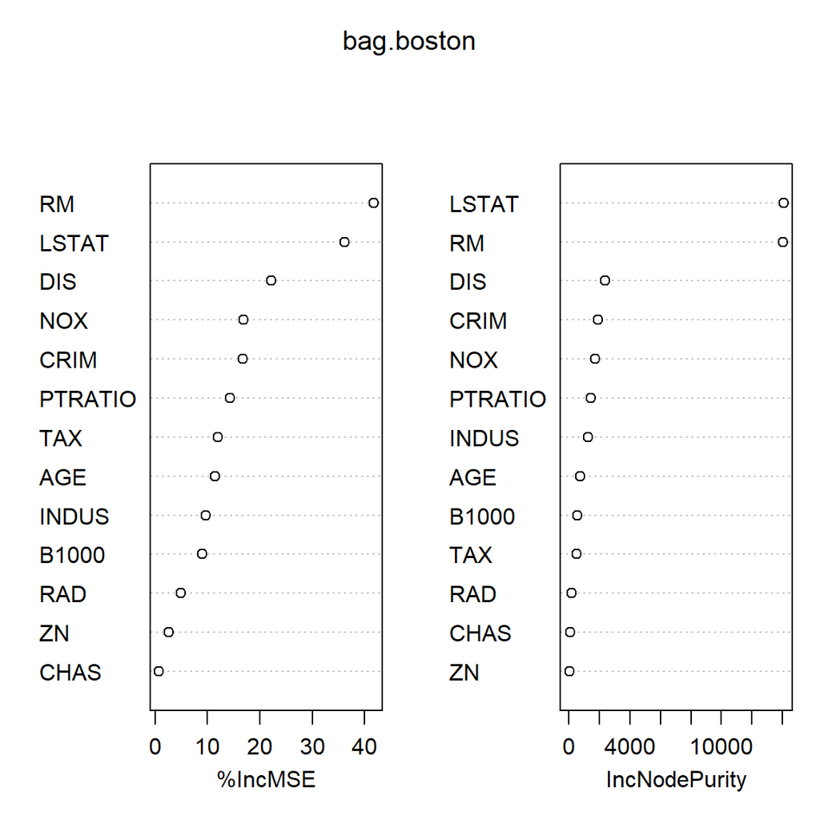

```r
varImpPlot(bag.boston)
```

```r
##prediction with optimized parameter
```

*5) Gradient Boosting Machine*

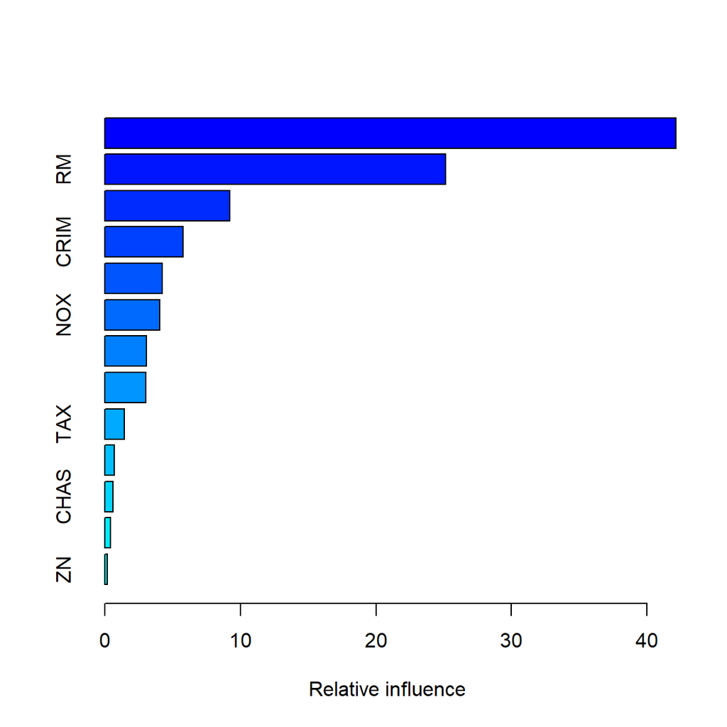

```
##             var    rel.inf
## LSTAT     LSTAT 42.1254976
## RM           RM 25.1571096
## DIS         DIS  9.2377776
## CRIM       CRIM  5.7640767
## AGE         AGE  4.2484342
## NOX         NOX  4.0325941
## PTRATIO PTRATIO  3.0863978
## B1000     B1000  3.0095573
## TAX         TAX  1.4545132
## INDUS     INDUS  0.7146295
## CHAS       CHAS  0.6057220
## RAD         RAD  0.3993636
## ZN           ZN  0.1643268
```

```r
library(gbm)
set.seed(1)
boost.boston=gbm(MEDV~.,data=boston_, distribution="gaussian", n.trees=5000,interaction.depth = 4)
summary(boost.boston)
```

```r
yhat.boost = predict(boost.boston, newdata=boston_test, n.trees=5000)
mean((yhat.boost - boston_test$MEDV)^2)
```

```
## [1] 11.95818
```

```r
fitControl <- trainControl(method = "repeatedcv", number = 10, repeats = 5, search = "random")
gbm.fit <- train(MEDV~ ., data = boston_, method = "gbm", trControl = fitControl, verbose = F, tuneLength=10)
gbm.fit
```

```
## Stochastic Gradient Boosting
##
## 455 samples
##  13 predictor
##
## No pre-processing
## Resampling: Cross-Validated (10 fold, repeated 5 times)
## Summary of sample sizes: 409, 410, 410, 409, 408, 409, ...
## Resampling results across tuning parameters:
##
##   shrinkage  interaction.depth  n.minobsinnode  n.trees  RMSE      Rsquared
##   0.1368062  6                  20              1282     3.487178  0.8602390
##   0.2415349  2                  24                86     3.752009  0.8360384
##   0.2663052  5                   7              2560     3.343860  0.8705725
##   0.2865887  5                  17              1593     3.484574  0.8599097
##   0.4110631  7                  12              4056     3.486135  0.8580923
##   0.4382509  4                  12              3465     3.676237  0.8444200
##   0.4471177  7                  25              1902     4.089732  0.8129875
##   0.5646165  3                   7               356     3.793480  0.8381233
##   0.5695762  7                  13              1923     3.966488  0.8212324
##   0.5918422  3                  25               272     4.055655  0.8139931
##   MAE
##   2.495001
##   2.686886
##   2.369605
##   2.502932
##   2.536842
##   2.663988
##   3.000871
##   2.744388
##   2.925324
##   2.992370
##
## RMSE was used to select the optimal model using the smallest value.
## The final values used for the model were n.trees = 2560, interaction.depth =
##  5, shrinkage = 0.2663052 and n.minobsinnode = 7.
```

```r
boost.boston=gbm(MEDV~.,data=boston_, distribution="gaussian", n.trees=2560, interaction.depth = 5, shrinkage = 0.2663052, n.minobsinnode = 7)
yhat.boost = predict(boost.boston, newdata=boston_test)
mean((yhat.boost - boston_test$MEDV)^2)
```

```
## [1] 10.30494
```